# High School Seniors t Test

```r
library(tidyverse)
library(DT)
library(pander)
library(readr)
library(car)
library(pander)

HSS <- read_csv("../../Data/HighSchoolSeniors.csv")
#Remember: select "Session, Set Working Directory, To Source File Location", and then play this R-chunk into your console to read the HSS data into R.

#HSS <- HSS %>% mutate(Armspan_cm = as.numeric(Armspan_cm), na.rm = TRUE)
#View(HSS)
```

## Background

These data are sorted out from the collected data by Census at School - U.S. Census at School Questionnaire. This analysis is to find if there is a relationship between video gaming hours and reaction time.

This analysis is trying to show that a group that plays more than the average hours (5.6 hours a week) of video games will react faster than those of a group that does not. In other words, some types of games require quick reactions, so we are assuming that those who play more than the average time unconsciously train to react quickly. Therefore, this analysis is trying to show the difference in the population means of reaction time by a group of students gaming more than 5.6 hours per week and a group of students gaming less than 5.6 hours per week, $\mu_1 - \mu_2$, is unequal which is the alternative hypothesis.

The null and alternative hypotheses are written as
$$H_0: \mu_\text{group 1} - \mu_\text{group 2} = 0$$
$$H_a: \mu_\text{group 1} - \mu_\text{group 2} \neq 0$$
$\star \text{ group 1: video gaming more than 5.6 hours per week}$

$\star \text{ group 2: video gaming less than 5.6 hours per week}$

The level of significance is
$$\alpha = 0.01$$

```r
HSS_g1 <- HSS_g %>% select(c("Video_Games_Hours", "Reaction_time"))

datatable(HSS_g1, options=list(lengthMenu = c(3,10,30)), extensions="Responsive") # (2) data table support the analysis by showing the data. It's not for readings. So, I am keepign this#
```

|  | Video_Games_Hours | Reaction_time |
| --- | --- | --- |
| 1 | 0 | 0.368 |
| 2 | 0 | 0.3 |
| 3 | 0 | 0.315 |
| 4 | 3 | 0.373 |
| 5 | 20 | 0.365 |
| 6 | 15 | 0.148 |
| 7 | 8 | 0.397 |
| 8 | 5 | 0.4 |
| 9 | 0 | 0.2824 |
| 10 | 2 | 0.355 |

[output cut: 279 more lines]

## Analysis

The reaction time data that are slower than 0.5 seconds are excluded. This analysis focuses on whether the reaction time is further reduced by playing video games among the two groups of students who are already reacting fast.

This boxplot shows that a group with the students who play games more than 5.6 hours a week average reaction time is slightly shorter than a group with the students who play games less than 5.6 hours a week.

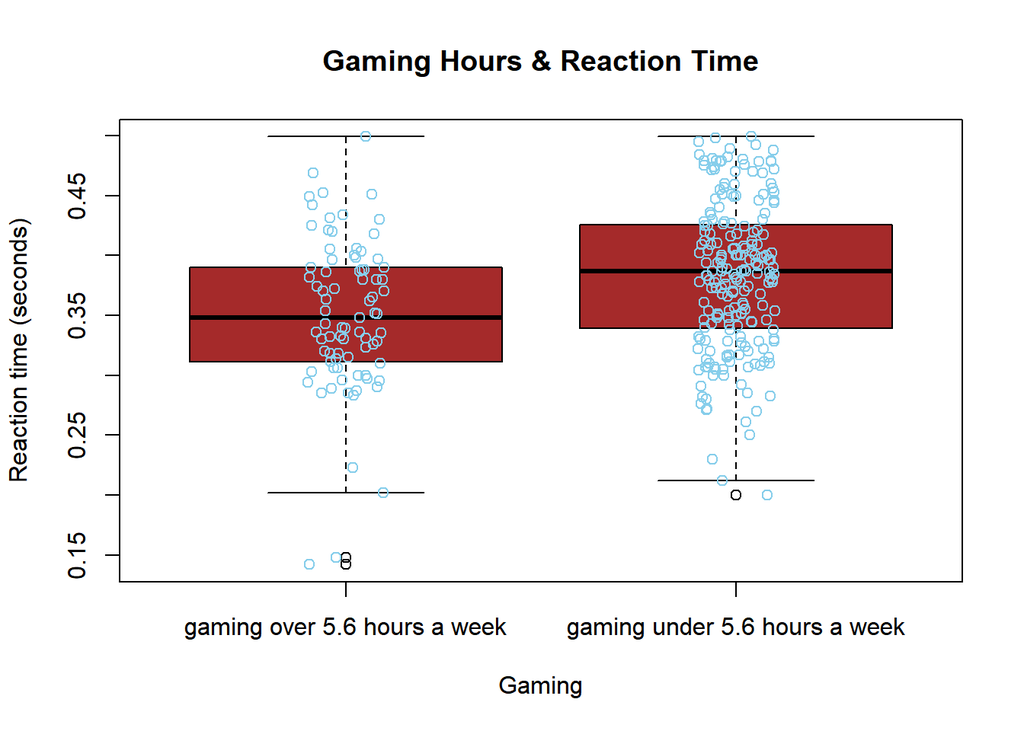

```r
boxplot(Reaction_time ~ Gaming, data = HSS_g, col = "brown",main = "Gaming Hours & Reaction Time", ylab = "Reaction time (seconds)", names = c("gaming over 5.6 hours a week", "gaming under 5.6 hours a week"))
stripchart(Reaction_time ~ Gaming, data = HSS_g, vertical = TRUE, method = "jitter", pch = 21, add = TRUE, col = "skyblue")
```

However, a conclusion cannot be made by only referring to the graph. The $\textit{Indepedent Sample t-Test}$ should be implemented to show the difference between the two means are different.

The test is appropriate only when both samples are representative of the population and when the sampling distribution of the difference of the sample means ($\bar{x}_1 - \bar{x}_2$) can be assumed to be normal. Additionally, it is safe to have sample sizes of more than 30. QQ-Plots and a table for the sample sizes will verify these preconditions.

```r
table(HSS_g$Gaming) %>% pander(caption = "Sample Sizes for each Group")
```

Sample Sizes for each Group

| Gaming over average a week | Gaming under average a week |
| --- | --- |
| 81 | 208 |

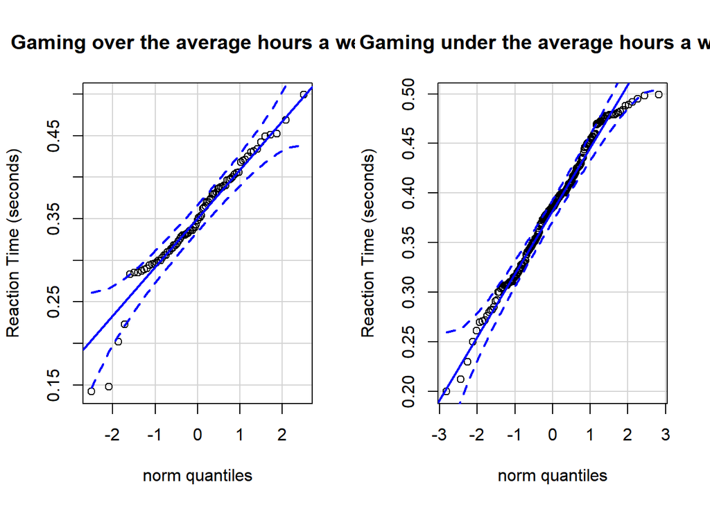

```r
#reaction time in seconds.
par(mfrow = c(1,2))

qqPlot(HSS_g$Reaction_time[HSS_g$Gaming == "Gaming over average a week"], ylab = "Reaction Time (seconds)", main = "Gaming over the average hours a week", id = FALSE)

qqPlot(HSS_g$Reaction_time[HSS_g$Gaming == "Gaming under average a week"], ylab = "Reaction Time (seconds)", main = "Gaming under the average hours a week", id = FALSE)
```

```r
#par(mfrow = c(1,1))
#qqPlot(Video_Games_Hours ~ Gaming, data = HSS_g, ylab = "Video Games Hours")
```

In the graphs, there are few outliers that exist, but the sample sizes are good and the samples are mostly inside of the dot lines which are the confidence intervals. Therefore, the data are approximately normal and the t-Test can be employed for these reasons.

```r
t.test(Reaction_time ~ Gaming, data = HSS_g, mu = 0, alternative = "two.sided", conf.level = 0.99 ) %>% pander(caption = "Two Independent Sample t-Test: Reaction Times (seconds) by the Groups by Video Game Hours a week. (alpha = 0.01)")
```

Two Independent Sample t-Test: Reaction Times (seconds) by the Groups by Video Game Hours a week. (alpha = 0.01) (continued below)

| Test statistic | df | P value | Alternative hypothesis |
| --- | --- | --- | --- |
| -3.918 | 141 | 0.0001389 * * * | two.sided |

| mean in group Gaming over average a week | mean in group Gaming under average a week |
| --- | --- |
| 0.3503 | 0.383 |

According to the t-Test result, $\textit{p-value}$, 0.0001, is smaller than the significance level, $\alpha = 0.01$. Therefore, the null hypothesis can be rejected safely.

## Conclusion

This analysis wanted to find out that the video gaming a week will affect shortening the reaction time. According to the boxplot and the t-Test table, a group that has students with playing games more than 5.6 hours (the average hour) a week has the lower mean value of the reaction time. By implementing the t-Test, the null hypothesis is rejected by comparing the $\textit{p-value}$ and the significance level, $\alpha$. As a conclusion, this analysis supports that playing video games more than the average hours a week affects shortening the reaction time. According to the t-Test result, the reduced reaction time by playing video games is 0.0327 seconds on average.